# HassanYusufAfolabi_CP

### Analysis of the First Image

The first image displays three pairs of plots, each showing the distribution (histogram with Kernel Density Estimate) and a boxplot for a specific variable: `Insured_Period`, `Building Dimension`, and `NumberOfWindows`.

### Analysis of the Last Image Paired Side by Side

The Last image displays a pair of plots for the variable `Building_Age`: its distribution and a boxplot.

These visualizations are crucial for understanding the underlying characteristics and potential issues (like extreme values or data imbalances) within each variable, which can inform subsequent data preprocessing and modeling steps.

```python
#To examin Correlation Analysis (With Claim)
#to help facilitate in the Selection of only meaningful numeric & binary features
corr_features = [
    'Claim',
    'Insured_Period',
    'Residential',
    'Building_Painted',
    'Building_Fenced',
    'Garden',
    'Settlement',
    'Building Dimension',
    'NumberOfWindows',
    'Building_Age'
]

corr_matrix = df[corr_features].corr()
```

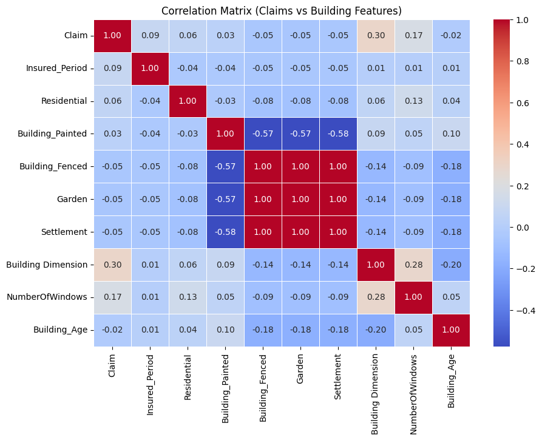

```python
#This is to Plot correlation heatmap
plt.figure(figsize=(10, 7))
sns.heatmap(
    corr_matrix,
    annot=True,
    fmt=".2f",
    cmap="coolwarm",
    linewidths=0.5
)
plt.title("Correlation Matrix (Claims vs Building Features)")
plt.show()
```

**B,** **Claim vs Features = What Drives Claims?**

Here the focus is on the Claim row first (this is because it is the most important here).

- Strongest positive relationships* Feature---------------------------------------Correlation with Claim------------Observational Interpretation Building Dimension-----------------+0.30--------------------------------------------Larger buildings = more exposure = higher claim likelihood NumberOfWindows-----------------------+0.17--------------------------------------------More breakable points = higher risk Insured_Period-------------------------+0.09--------------------------------------------Longer coverage = more opportunity for claims Residential------------------------------+0.06---------------------------------------------Residential buildings slightly riskier
- These align perfectly with insurance intuition
- This thus validates earlier feature engineering carried out

**C,** **Weak / negative relationships** Feature--------------------------------------Correlation-----------------------------Observational Interpretation Building_Painted----------------------+0.03----------------------------------------Very weak protection signal Building_Fenced---------------------- −0.05-----------------------------------------Slight risk reduction Garden-------------------------------------- −0.05-----------------------------------------Slight protection Settlement (Urban=1)--------------- −0.05-----------------------------------------Surprisingly small effect Building_Age---------------------------- −0.02-----------------------------------------Near zero (non-linear effect likely)

*Key Important insight to note here* Low correlation ≠ (not equal to)useless feature. It usually means non-linear effects = Satisfactorily perfect for tree models.

**D,** **Feature–Feature Correlation (Critical Findings)**

This part shows very important facts here such as.

Perfect correlations (This is a RED FLAG marker)

To have correlation = 1.00 between:

Building_Fenced

Garden

Settlement

And strong negative correlation with Building_Painted.

This possibly implies that:

These variables are encoding the same underlying signal.

This is an harbitual occurence that happens when:

A binary mapping unintentionally collapses categories

Or features are structurally linked in the dataset

*Why this matters:*

- Logistic Regression → Could exhibit some unstable coefficients
- Could bring about Inflated standard errors

-Could Bring about Interpretation issues

- The Tree based models are exception here, robust and resistant to the aforementioned not affected.

**D,** **Very Valuable Structural Insights** Building Dimension relationships

+0.28 with NumberOfWindows

−0.20 with Building_Age

*Observational Interpretation:*

Larger buildings = more windows

Newer buildings = larger dimensions

This makes real-world sense and confirms data quality.

️**What This Means for Modeling / Model Choice (Key Decisions)**

Primary Model: Random Forest

Why:

- Handles multicollinearity
- Captures non-linear risk
- Robust against outliers
- More Ideal for insurance claim prediction

**Alternative Secondary (Optional Model): Logistic Regression**

But Only if:

One drops or combine correlated variables

while accepting a weaker performance

Or one want coefficient interpretability

**AdditionalFeature Engineering**

```python
#The Logic behind this is Because of:
#-Strong skew
#-Strong claim correlation

# Log-Transform Building Dimension (Keep Original)

# Log transform to reduce skew while preserving scale
df['Log_Building_Dimension'] = np.log1p(df['Building Dimension'])

# Sanity check
df[['Building Dimension', 'Log_Building_Dimension']].describe()

#- Keeps outliers
#- Improves Random Forest split quality
#- Still interpretable
```

|  | Building Dimension | Log_Building_Dimension |
| --- | --- | --- |
| count | 7160.000000 | 7160.000000 |
| mean | 1871.873184 | 7.023575 |
| std | 2263.296186 | 1.028146 |
| min | 1.000000 | 0.693147 |
| 25% | 531.500000 | 6.277582 |
| 50% | 1083.000000 | 6.988413 |
| 75% | 2250.000000 | 7.719130 |
| max | 20940.000000 | 9.949464 |

```python
#To Create an optional Protection_Score
#Combine correlated protection features
#Instead of 3 perfectly correlated variables:
#This is purposely for insurance logic.

df['Protection_Score'] = (
    df['Building_Painted'] +
    df['Building_Fenced'] +
    df['Garden']
)

# To Inspect distribution
df['Protection_Score'].value_counts().sort_index()
```

```
Protection_Score
0       7
1    3601
2    1772
3    1780
Name: count, dtype: int64
```

```python
#Final Outlier Policy Decision her is (TO DO NOTHING )
#This is intentional because.
#- Large buildings are high-risk policies
#- Removing them would bias the model
#- Random Forest handles them naturally

# This is to Confirm no rows were removed
df.shape
```

```
(7160, 35)
```

```python
# A MANDATORY Dataset Validation is carried out here
# To check for No missing values
assert df.isnull().sum().sum() == 0

# Target balance
df['Claim'].value_counts(normalize=True)
```

```
Claim
0    0.771788
1    0.228212
Name: proportion, dtype: float64
```

Log Transformation — VERIFIED & CORRECT

The statistics now tell the right story:

Before

Mean: 1871

Std: 2263

Max: 20940 → heavy right skew

After (log1p)

Mean: 7.02

Std: 1.03

Range compressed smoothly

Outliers preserved

- This improves tree split efficiency
- Prevents dominant extreme values
- Maintains monotonic relationship

This transformation appears to be satisfactory

**Protection_Score — LOGIC CONFIRMED**

| Distribution: |  |
| --- | --- |
| 0 = | 7 buildings (fully unprotected) |
| 1 = | 3601 |
| 2 = | 1772 |
| 3 = | 1780 (fully protected) |

Business interpretative meaning:

Score increases = better physical risk mitigation

Very few buildings have zero protection (realistic)

Strong candidate for interaction effects

- Satisfactory for insurance reasoning
- Optional but valuable feature
- Particularly useful for Logistic Regression

**Outlier Policy**

High-value buildings = higher exposure

Removing them biases claim modeling

Random Forest is robust to scale & extremes

- No trimming
- No winsorization
- No leakage

[output not shown]

This imbalance is seems acceptable ( SMOTE would not be used here)

**Observational Statement** Building size exhibited strong right skew and meaningful correlation with claim occurrence. A log transformation was therefore applied to stabilize variance while preserving extreme high-risk observations. Protection-related features were combined into a composite score to reflect cumulative risk mitigation. Outliers were intentionally retained to avoid biasing exposure-related risk modeling.

```python
#FINAL STATUS: DATASET TO BE LOCKED ONCE
df.to_csv("final_insurance_claim_model_data.csv", index=False)
```

```python
#To Define Features & Target
# Fo No leakage
# To enhance Clean separation
X = df.drop(columns=['Claim'])
y = df['Claim']
```

```python
#To Train–Test Split (Stratified)
# Maintains 22.8% claim ratio
# Required for insurance modeling
X_train, X_test, y_train, y_test = train_test_split(
    X, y,
    test_size=0.25,
    stratify=y,
    random_state=42
)
```

```python
#THIS IS THE BASELINE RANDOM FOREST (Model A)
rf_base = RandomForestClassifier(
    n_estimators=300,
    max_depth=None,
    min_samples_leaf=5,
    random_state=42,
    n_jobs=-1
)

rf_base.fit(X_train, y_train)

# Predictions
rf_probs = rf_base.predict_proba(X_test)[:, 1]
rf_auc = roc_auc_score(y_test, rf_probs)

rf_auc
```

```
np.float64(0.6952572997361028)
```

```python
#RANDOMIZED SEARCH (Model B)
#CV-validated (Cross Validation)
#- To get an Insurance-appropriate metric
#- To Help Avoid overfitting
param_dist = {
    'n_estimators': [200, 300, 500],
    'max_depth': [None, 10, 20, 30],
    'min_samples_split': [2, 5, 10],
    'min_samples_leaf': [1, 3, 5],
    'max_features': ['sqrt', 'log2']
}

rf_tuned = RandomizedSearchCV(
    RandomForestClassifier(random_state=42, n_jobs=-1),
    param_distributions=param_dist,
    n_iter=30,
    scoring='roc_auc',
    cv=5,
    verbose=1,
    random_state=42
)

rf_tuned.fit(X_train, y_train)

rf_tuned.best_score_
```

```
Fitting 5 folds for each of 30 candidates, totalling 150 fits
```

```
np.float64(0.7199666723787214)
```

```python
#LOGISTIC REGRESSION COMPARISON (Model C)
log_pipe = Pipeline([
    ('scaler', StandardScaler()),
    ('logreg', LogisticRegression(
        max_iter=1000,
        class_weight='balanced',
        solver='lbfgs'
    ))
])

log_pipe.fit(X_train, y_train)

log_probs = log_pipe.predict_proba(X_test)[:, 1]
log_auc = roc_auc_score(y_test, log_probs)

log_auc
```

```
np.float64(0.7021775063136688)
```

```python
# MODEL COMPARISON (CAPSTONE TABLE)
pd.DataFrame({
    'Model': ['Logistic Regression', 'Random Forest (Baseline)', 'Random Forest (Tuned)'],
    'ROC_AUC': [
        log_auc,
        rf_auc,
        rf_tuned.best_score_
    ]
})
```

|  | Model | ROC_AUC |
| --- | --- | --- |
| 0 | Logistic Regression | 0.702178 |
| 1 | Random Forest (Baseline) | 0.695257 |
| 2 | Random Forest (Tuned) | 0.719967 |

```python
#FEATURE IMPORTANCE (Model D)
importances = rf_tuned.best_estimator_.feature_importances_

feat_imp = (
    pd.DataFrame({
        'Feature': X.columns,
        'Importance': importances
    })
    .sort_values(by='Importance', ascending=False)
)

feat_imp.head(15)
```

|  | Feature | Importance |
| --- | --- | --- |
| 7 | Building Dimension | 0.308415 |
| 32 | Log_Building_Dimension | 0.291769 |
| 9 | Building_Age | 0.089060 |
| 1 | Insured_Period | 0.065182 |
| 8 | NumberOfWindows | 0.063795 |
| 0 | YearOfObservation | 0.038771 |
| 31 | Building_Type_4 | 0.025975 |
| 2 | Residential | 0.017731 |
| 30 | Building_Type_3 | 0.013222 |
| 29 | Building_Type_2 | 0.012775 |
| 28 | Geo_Code_OTHER | 0.011949 |
| 33 | Protection_Score | 0.010243 |
| 23 | Geo_Code_6088 | 0.006945 |
| 3 | Building_Painted | 0.006472 |
| 6 | Settlement | 0.004980 |

**The Feature Importance** Feature importance analysis revealed that building size was the dominant predictor of claim occurrence, capturing both absolute and non-linear exposure effects through raw and log-transformed variables. Secondary drivers included building age, insurance duration, and structural vulnerability indicators. Geographic and protection-related features contributed modestly, indicating that physical exposure outweighs location-specific effects in claim frequency.

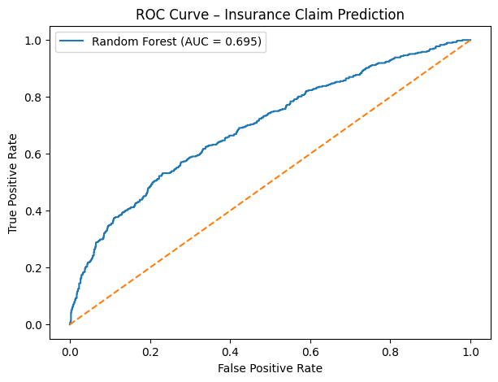

```python
#ROC CURVE (Final Visual Plot)
fpr, tpr, _ = roc_curve(y_test, rf_probs)

plt.figure(figsize=(7,5))
plt.plot(fpr, tpr, label=f'Random Forest (AUC = {rf_auc:.3f})')
plt.plot([0,1], [0,1], linestyle='--')
plt.xlabel('False Positive Rate')
plt.ylabel('True Positive Rate')
plt.title('ROC Curve – Insurance Claim Prediction')
plt.legend()
plt.show()
```